# A whirlwind tour of Quarto and the Tidyverse

Author

Paul M. Magwene

# Installing packaages

See in class demo on the Packages install dialog.

- Install the tidyverse package

# Loading packages

Once a package is installed we can load it the the `library` function:

```r
library(tidyverse)
```

# Quarto

Quarto is a tool for scientific documentation and publishing. In this class we’ll be using Quarto documents as the primary method for writing, testing, and exploring R code.

## In-class tour of Quarto

- Create a Quarto document
- Review Quarto interface in RStudio
- Visual vs Source editor view
- Code blocks
- Interactive notebook model vs document rendering – discuss differences and possible points of confusion about execution models
  - Take home: When testing your notebooks (e.g. homeworks!) use the `Session > Restart R and Run All Chunks` menu item to make sure your code runs without error

# Data import using the readr package

The `readr` package is one of the libraries included when we installed the tidyverse. The readr package provide a wide variety of functions for loading common data formats like CSV, TSV, and other delimited data types.

## Load a data file using `readcsv`

Download `penguins.csv`

```r
penguins <- read_csv("~/Bio724/penguins.csv")
```

# Simple data frame manipulations

When the penguins data set is loaded it is treated as a “data frame”, which is an R data structure that represents tabular data. The data frame is the data structure we’ll be using most often in this class.

Basic functions for getting a handle on what’s in a data frame

- `View`
- `dim`
- `head` and `tail`
- `str`

# Basic plots

## Raw data plot and jittering

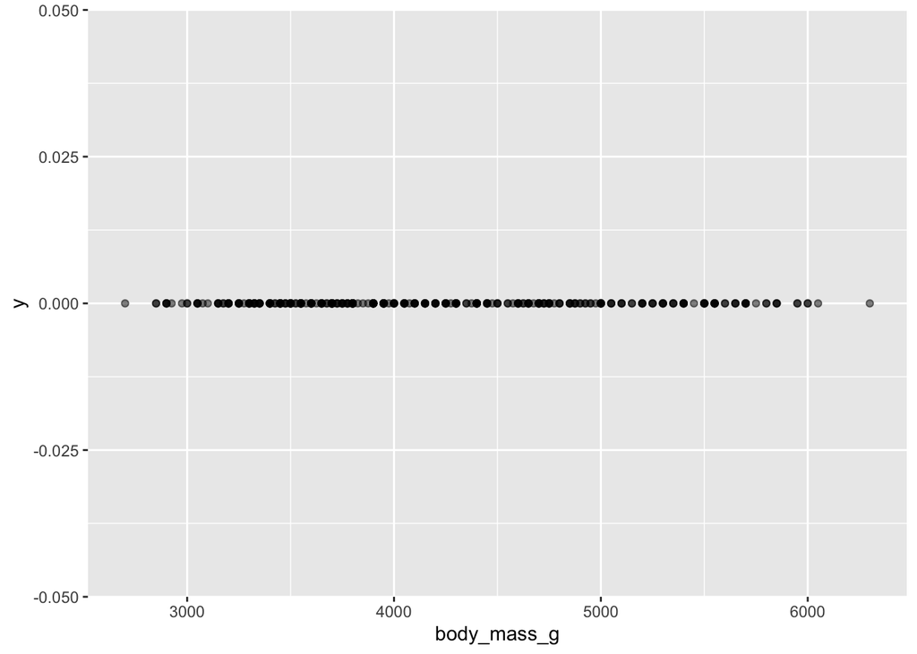

```r
ggplot(penguins, aes(x = body_mass_g, y = 0)) +
  geom_point(alpha=0.5)
```

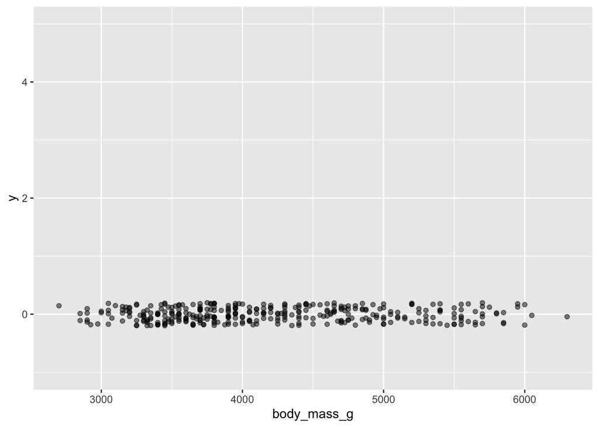

```r
ggplot(penguins, aes(x = body_mass_g, y = 0)) +
  geom_jitter(width=0, height=0.2, alpha=0.5) +
  ylim(-1, 5)
```

## Histograms

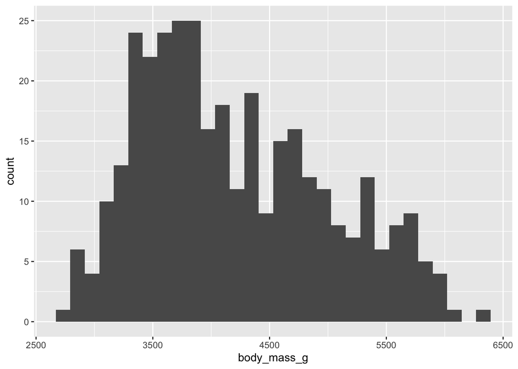

```r
ggplot(penguins, aes(x = body_mass_g)) +
  geom_histogram()
```

## Density plots

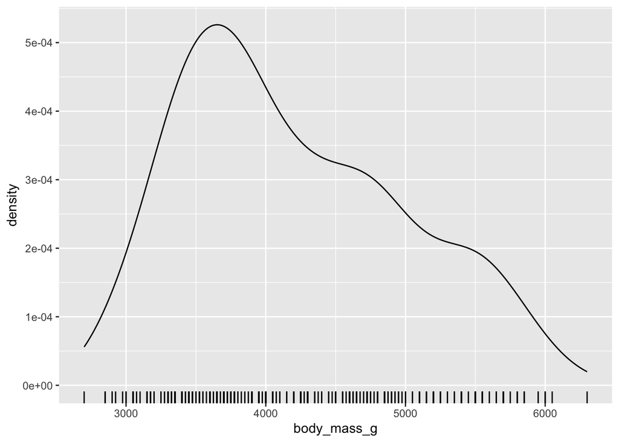

```r
ggplot(penguins, aes(x = body_mass_g)) +
  geom_density() +
  geom_rug()
```

## Violin plots

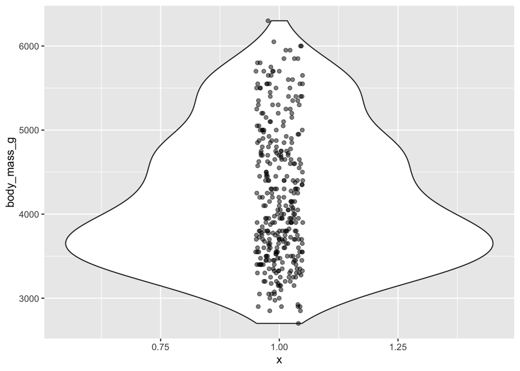

```r
ggplot(penguins, aes(x = 1, y = body_mass_g)) +
  geom_violin() +
  geom_jitter(height=0, width=0.05, alpha=0.5)
```

## Boxplots

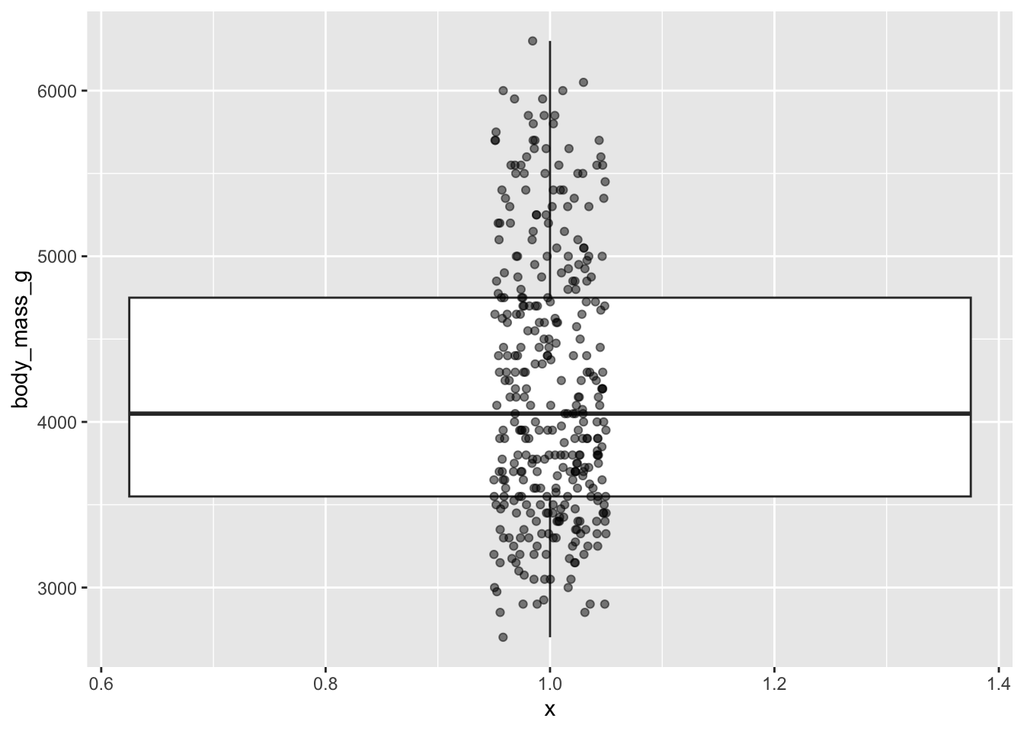

```r
ggplot(penguins, aes(x = 1, y = body_mass_g)) +
  geom_boxplot() +
  geom_jitter(height=0, width=0.05, alpha=0.5)
```

## Representing a categorical variable

- Raw data

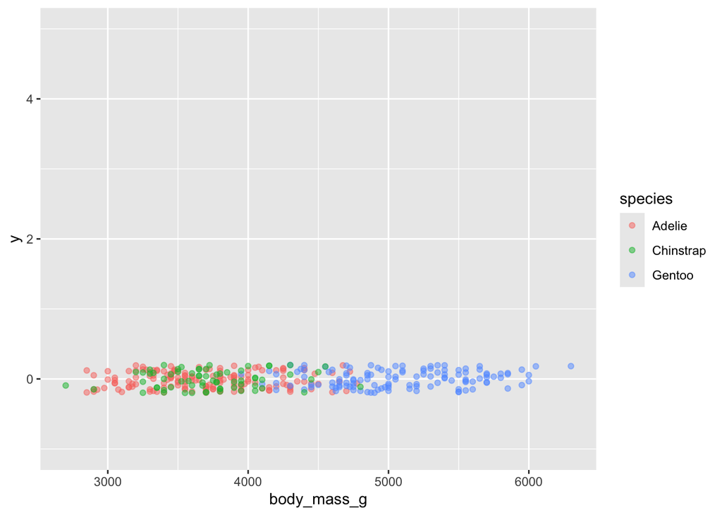

```r
ggplot(penguins, aes(x = body_mass_g, y = 0, color=species)) +
  geom_jitter(width=0, height=0.2, alpha=0.5) +
  ylim(-1, 5)
```

- Histogram

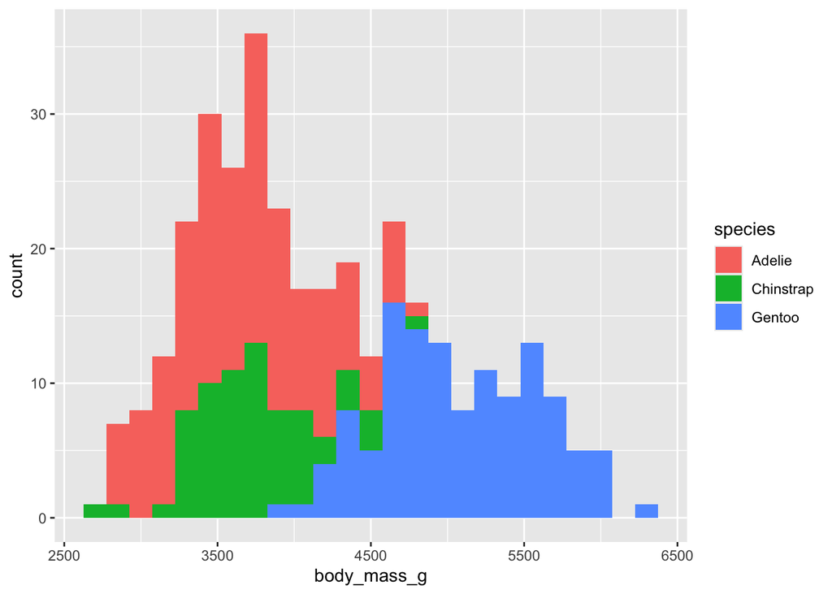

```r
ggplot(penguins, aes(x = body_mass_g, fill = species)) +
  geom_histogram(bins=25)
```

Note the above is a stacked histogram, not three different histograms.

To represent each of the species with it’s own histogram we need to specifying the position argument as below.

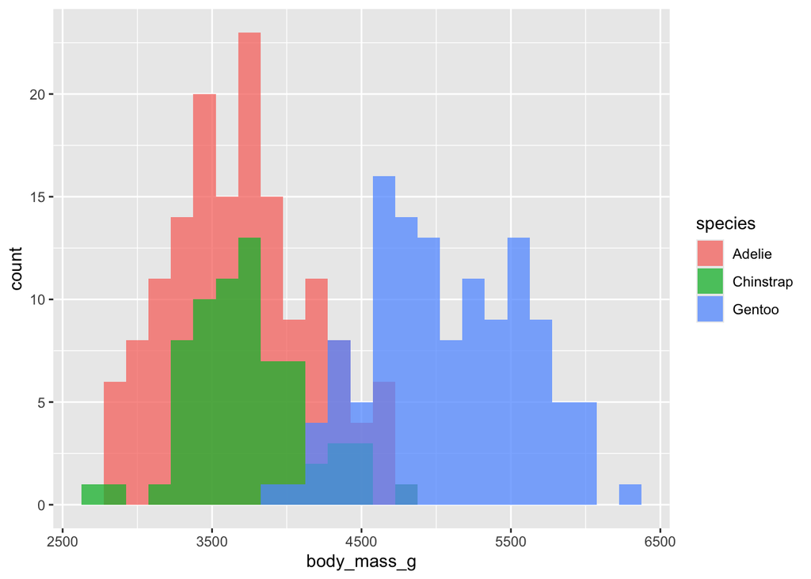

```r
ggplot(penguins, aes(x = body_mass_g, fill = species)) +
  geom_histogram(bins=25, position="identity", alpha=0.75)
```

- Density plots

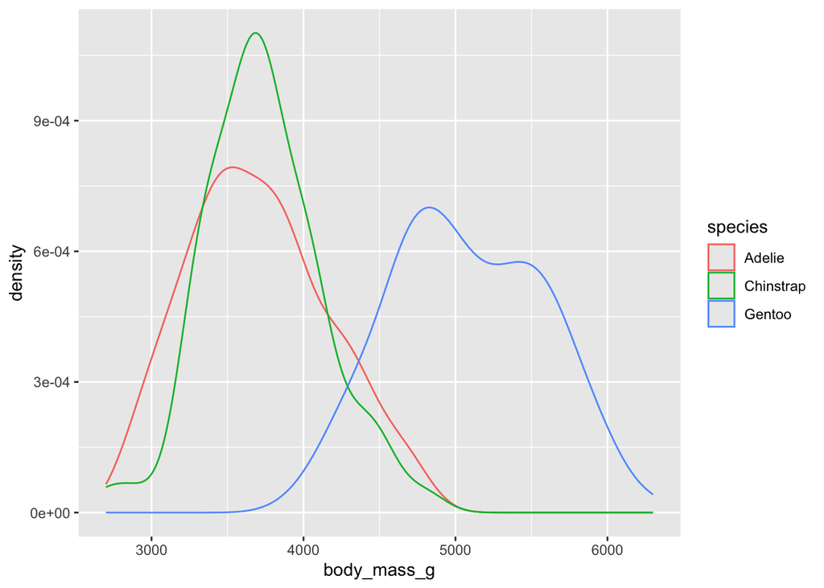

```r
ggplot(penguins, aes(x = body_mass_g, color = species)) +
  geom_density()
```

- Violin plot w/raw data depicted

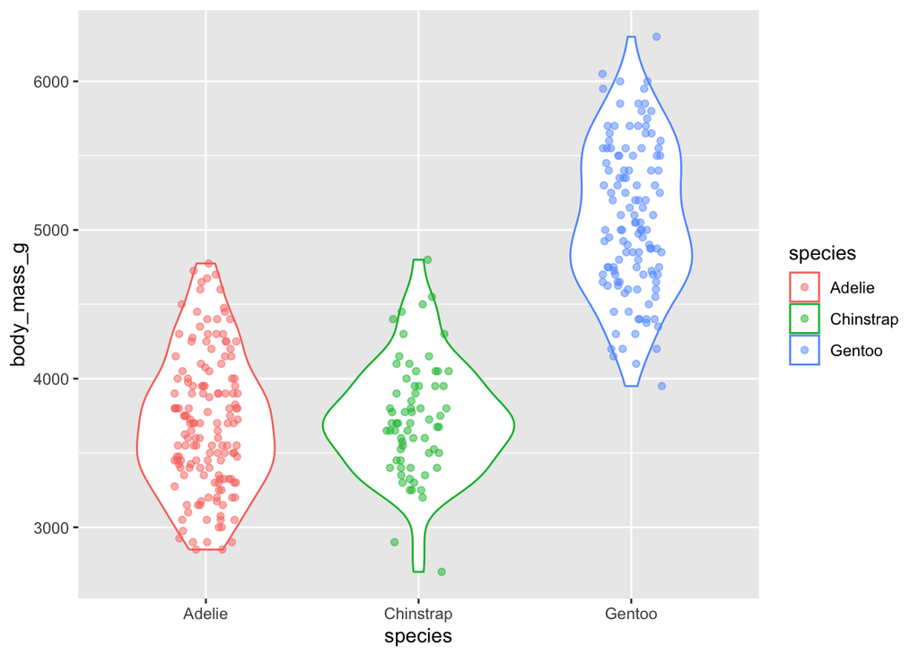

```r
ggplot(penguins, aes(x = species, y = body_mass_g, color=species)) +
  geom_violin() +
  geom_jitter(height=0, width=0.15, alpha=0.5)
```

- Boxplot w/raw data

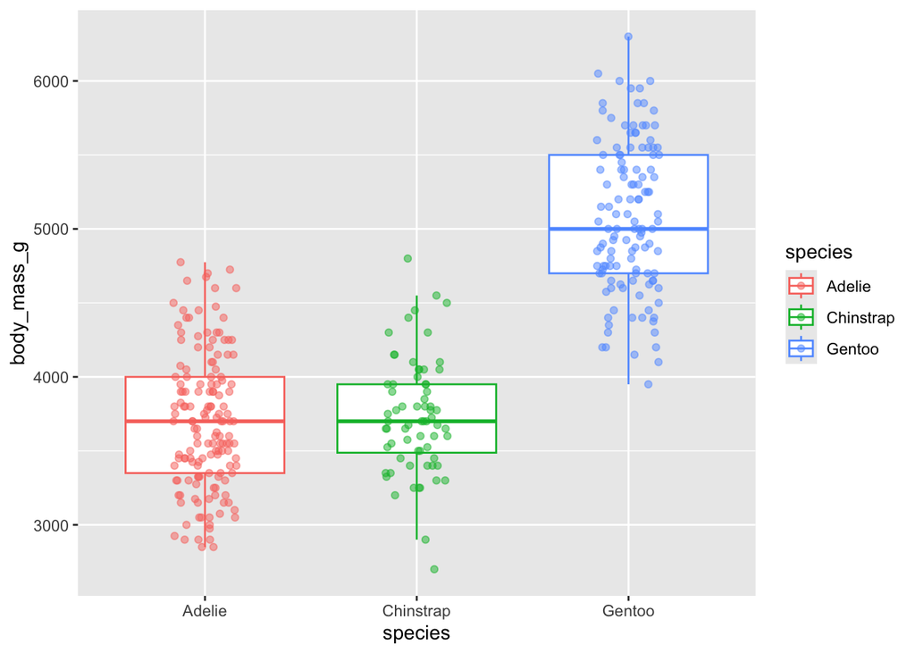

```r
ggplot(penguins, aes(x = species, y = body_mass_g, color=species)) +
  geom_boxplot(outliers = FALSE) +
  geom_jitter(height=0, width=0.15, alpha=0.5)
```

# Faceting

Faceting is equivalent to generating plots of the conditional distributions of one or more categorical variable:

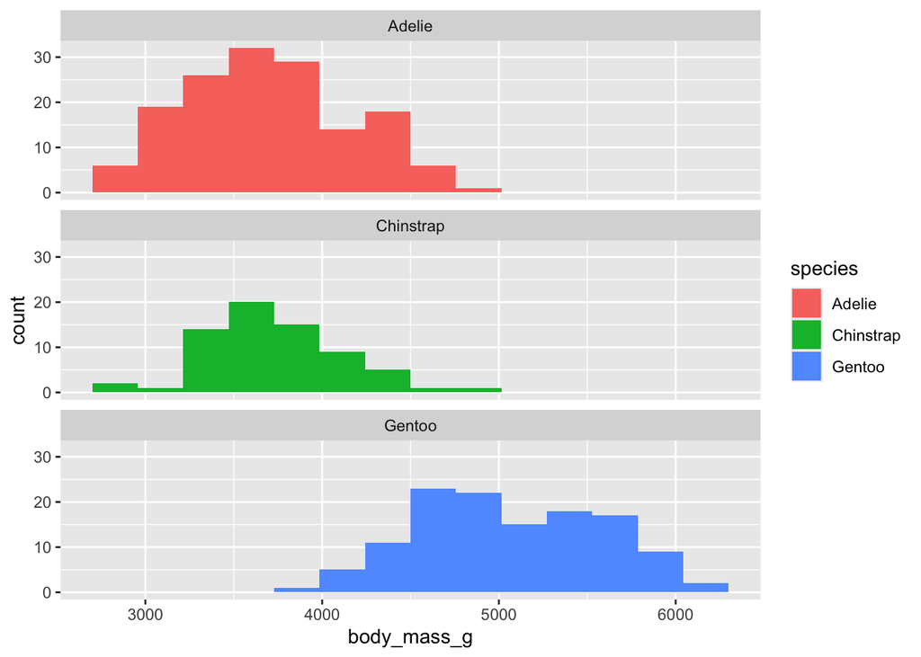

```r
ggplot(penguins, aes(x = body_mass_g, fill = species)) +
  geom_histogram(bins=15) +
  facet_wrap(~species, ncol=1)
```

# Some basic data analysis

`na.rm` require here to remove missing data before calculating means and standard deviations.

```r
penguins |>
  summarize(mean_bodymass = mean(body_mass_g, na.rm = TRUE),
            sd_bodymass = sd(body_mass_g, na.rm = TRUE))
```

```
# A tibble: 1 × 2
  mean_bodymass sd_bodymass
          <dbl>       <dbl>
1         4202.        802.
```

Alternate approach is to remove observations with `NA` values

```r
penguins |>
  filter(!is.na(body_mass_g)) |>  # filter out the NA values before summarize
  summarize(mean_bodymass = mean(body_mass_g),
            sd_bodymass = sd(body_mass_g))
```

```
# A tibble: 1 × 2
  mean_bodymass sd_bodymass
          <dbl>       <dbl>
1         4202.        802.
```

If we want the conditional means and standard deviations we can use `group_by` before summarize. Note the parallel with faceting above.

```r
penguins |>
  filter(!is.na(body_mass_g)) |>
  group_by(species) |>
  summarize(mean_bodymass = mean(body_mass_g),
            sd_bodymass = sd(body_mass_g))
```

```
# A tibble: 3 × 3
  species   mean_bodymass sd_bodymass
  <chr>             <dbl>       <dbl>
1 Adelie            3701.        459.
2 Chinstrap         3733.        384.
3 Gentoo            5076.        504.
```

## ANOVA to test difference in group means

```r
anova_bodymass <- aov(body_mass_g ~ species, data = penguins)
anova_bodymass
```

```
Call:
   aov(formula = body_mass_g ~ species, data = penguins)

Terms:
                  species Residuals
Sum of Squares  146864214  72443483
Deg. of Freedom         2       339

Residual standard error: 462.2744
Estimated effects may be unbalanced
2 observations deleted due to missingness
```

Generate standard ANOVA output table

```r
summary(anova_bodymass)
```

```
             Df    Sum Sq  Mean Sq F value Pr(>F)
species       2 146864214 73432107   343.6 <2e-16 ***
Residuals   339  72443483   213698
---
Signif. codes:  0 '***' 0.001 '**' 0.01 '*' 0.05 '.' 0.1 ' ' 1
2 observations deleted due to missingness
```

# Bivariate plots

- Scatter plots

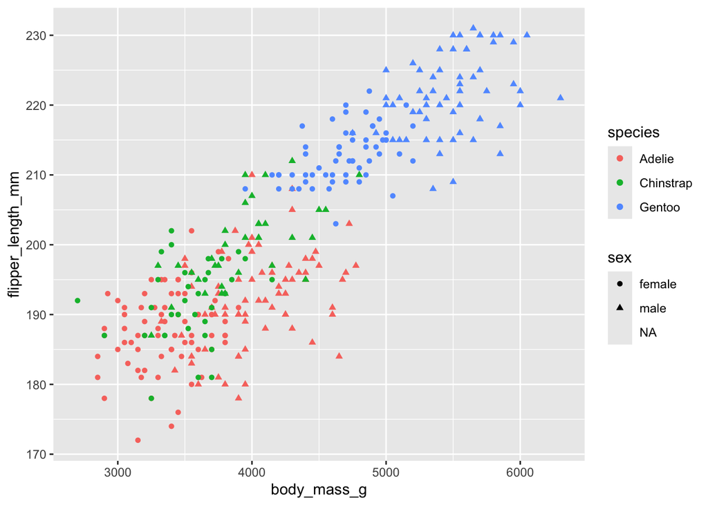

```r
ggplot(penguins, aes(x = body_mass_g,
                     y = flipper_length_mm,
                     color = species,
                     shape = sex)) +
  geom_point()
```

# Basic filtering with dplyr

```r
penguins_filtered <-
  filter(penguins, !is.na(sex), species != "Gentoo")
```

Notice the legend no longer includes NA, and we’ve also filtered out all the Gentoo penguins.

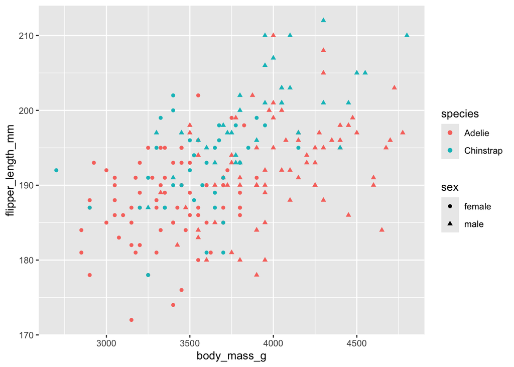

```r
ggplot(penguins_filtered, aes(x = body_mass_g,
                     y = flipper_length_mm,
                     color=species,
                     shape=sex)) +
  geom_point()
```

# Faceting on multiple variables

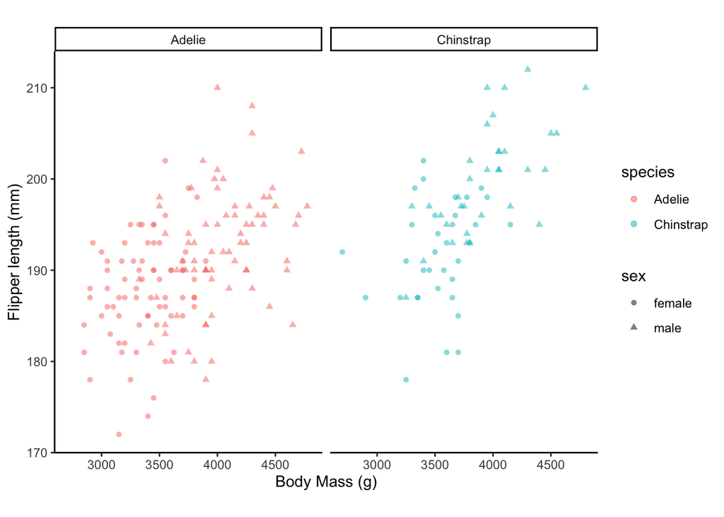

```r
ggplot(penguins_filtered, aes(x = body_mass_g,
                     y = flipper_length_mm,
                     color=species,
                     shape=sex)) +
  geom_point(alpha=0.5) +
  facet_wrap(~species) +
  labs(x = "Body Mass (g)", y = "Flipper length (mm)") +
  theme_classic() +
  theme(aspect.ratio = 1.5)
```

## 2D density plot

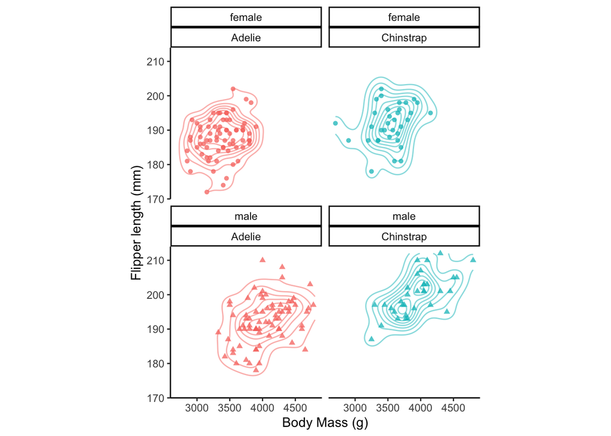

```r
ggplot(penguins_filtered, aes(x = body_mass_g,
                     y = flipper_length_mm,
                     color=species,
                     shape=sex)) +
  geom_point(alpha=0.75) +
  geom_density2d(alpha=0.5) +
  facet_wrap(sex~species) +
  labs(x = "Body Mass (g)", y = "Flipper length (mm)") +
  theme_classic() +
  theme(legend.position = "none",
        aspect.ratio=1)
```

# Grouping on multiple variables to produce summaries of interest

```r
penguins_filtered |>
  group_by(species, sex) |>
  summarise(across(c(body_mass_g, flipper_length_mm),
                   list(mean = mean, sd = sd)))
```

```
# A tibble: 4 × 6
# Groups:   species [2]
  species   sex    body_mass_g_mean body_mass_g_sd flipper_length_mm_mean
  <chr>     <chr>             <dbl>          <dbl>                  <dbl>
1 Adelie    female            3369.           269.                   188.
2 Adelie    male              4043.           347.                   192.
3 Chinstrap female            3527.           285.                   192.
4 Chinstrap male              3939.           362.                   200.
# ℹ 1 more variable: flipper_length_mm_sd <dbl>
```